# Final Project, P3: EDA

Nathaniel Evans, ALfonso Poire, Wei-Chun Lin

November 23, 2018

# 1 Overview

### 1.0.1 PAPER: [Hair cortisol levels, psychological stress and psychopathological symptoms as predictors of postpartum depression](https://journals.plos.org/plosone/article?id=10.1371/journal.pone.0182817)

### 1.0.2 DATA: [sav file](https://figshare.com/articles/PPD_hairCortisol_PlosOne_sav/5255848/1)

### 1.0.3 TIDY DATA: csv file

### 1.0.4 CODE BOOK: knitted html

#### 1.0.4.1 The purpose of this R markdown script is to explore the data provided by this paper. If desired, you can clone the the [github repository](https://github.com/OHSU-Math630/FINAL_PROJECT) and access this script within the cloned file strucutre (located: FINAL_PROJECT/postpartum_depression_predicition/P2/group7_DataDelivery.Rmd).

## 1.1 Load Tidy Dataset

```r
getwd()
```

```
## [1] "C:/R/final project/FINAL_PROJECT/postpartum_depression_prediction/P3"
```

```r
load('../../data/tidy_data.Rdata')

pp_sad <- df_tidy # rename meaningful
```

# 2 Examine Raw Data

### 2.0.1 All the variables are of a numeric type, although, many are discrete options that are mapped to categorical variables in the codebook.

### 2.0.2 For more in-depth summary of each variable, please refer to our codebook, submitted with this Project.

```r
glimpse(pp_sad)
```

```
## Observations: 44
## Variables: 21
## $ age                   <dbl> 32, 34, 29, 29, 32, 30, 36, 36, 31, 34, ...
## $ education_level       <dbl> 3, 2, 3, 3, 3, 3, 3, 3, 3, 3, 3, 3, 3, 2...
## $ nationality           <dbl> 1, 1, 1, 1, 1, 1, 0, 1, 1, 1, 1, 1, 1, 1...
## $ postpartum_depression <dbl> 1, 2, 1, 1, 2, 1, 2, 2, 1, 1, 1, 1, 1, 2...
## $ employed              <dbl> 1, 0, 0, 1, 1, 1, 1, 1, 1, 1, 1, 0, 1, 1...
## $ occupation            <dbl> 2, 1, 1, 1, 2, 2, 3, 3, 3, 7, 2, 1, 6, 4...
## $ sport                 <dbl> 0, 0, 1, 1, 1, 1, 1, 1, 1, 0, 1, 1, 0, 0...
## $ pet                   <dbl> 1, 0, 0, 0, 0, 0, 0, 0, 1, 0, 0, 0, 0, 1...
## $ dyed_hair             <dbl> 0, 1, 0, 1, 0, 1, 0, 0, 1, 1, 0, 1, 0, 0...
## $ first_pregnancy       <dbl> 1, 1, 0, 1, 0, 1, 1, 0, 1, 0, 0, 1, 1, 0...
## $ wanted_pregnancy      <dbl> 1, 1, 1, 1, 1, 1, 1, 1, 1, 1, 0, 1, 1, 1...
## $ pregnancy_method      <dbl> 1, 0, 1, 1, 1, 1, 0, 1, 1, 1, 1, 1, 0, 1...
## $ previous_miscarriage  <dbl> 0, 0, 0, 0, 1, 0, 0, 1, 0, 0, 0, 0, 0, 1...
## $ fetus_sex             <int> 1, 1, 0, 0, 1, 1, 0, 1, 1, 0, 1, 0, 0, 1...
## $ epds                  <dbl> 8, 15, 5, 4, 12, 3, 24, 10, 3, 6, 3, 3, ...
## $ depression_tri1       <dbl> 30.00000, 97.00000, 82.00000, 92.00000, ...
## $ depression_tri2       <dbl> 35.00000, 85.00000, 75.00000, 90.00000, ...
## $ depression_tri3       <dbl> 35.00000, 65.00000, 60.00000, 90.00000, ...
## $ cortisol_tri1         <dbl> 282.4000, 362.3000, 124.7000, 113.4900, ...
## $ cortisol_tri2         <dbl> 246.0000, 156.1000, 171.5000, 167.1000, ...
## $ cortisol_tri3         <dbl> 295.6000, 539.8000, 318.1000, 192.2000, ...
```

```r
# summary(pp_sad)
```

# 3 Biological predictors of Postparatum Depression

## 3.1 Depression to PP threshold

### 3.1.1 How does depression scores map to postpartum_depression labels? Might there be a better threshold cuttoff?

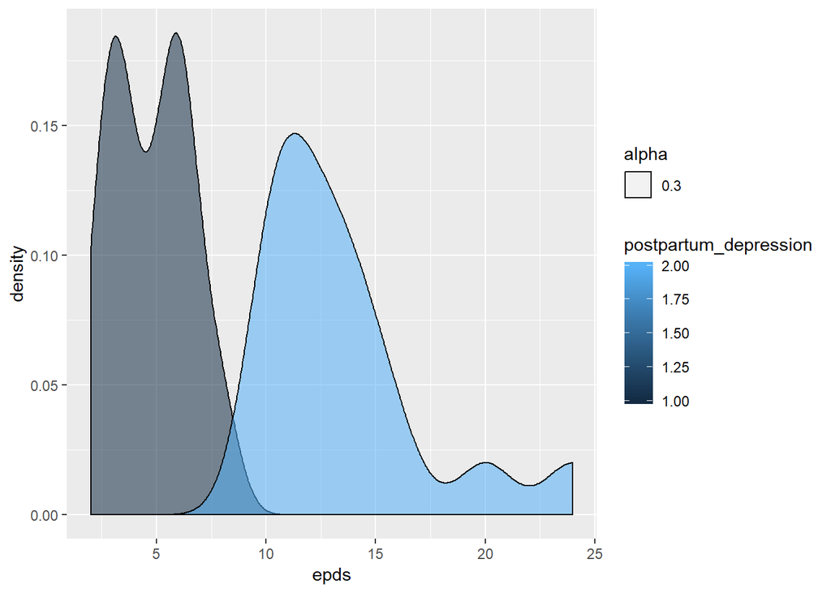

```r
pp_sad %>% ggplot() + geom_density(aes(x=epds, group=postpartum_depression, fill = postpartum_depression, alpha=0.3, bins=50))
```

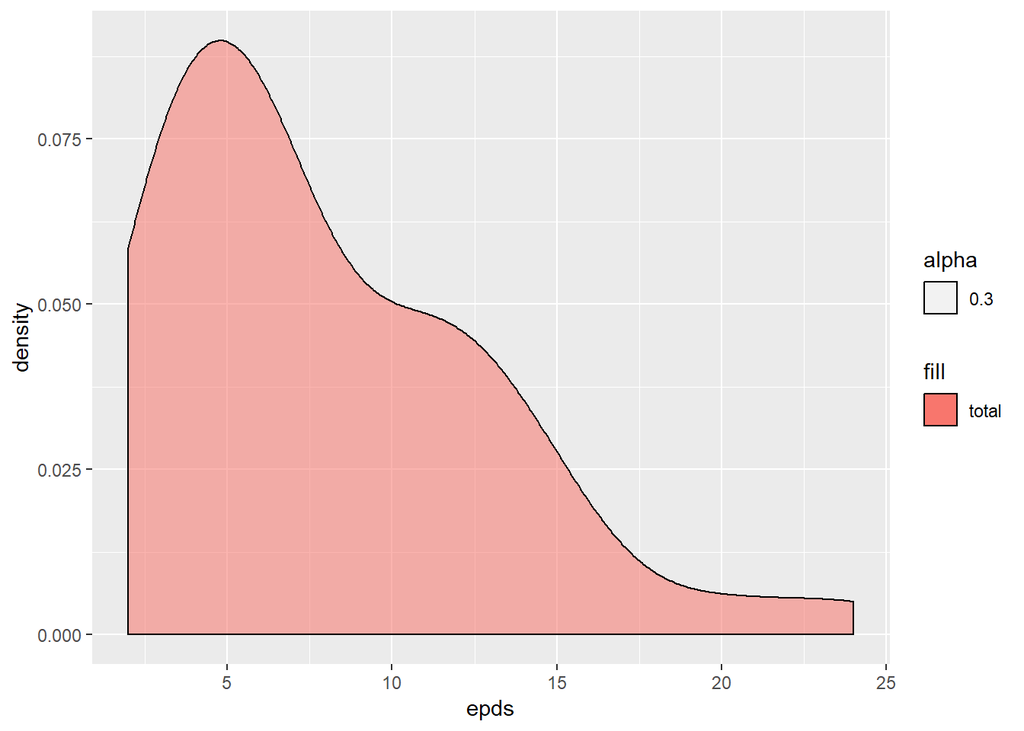

```r
pp_sad %>% ggplot() + geom_density(aes(x=epds, fill = 'total', alpha=0.3))
```

## 3.2 Cortisol vs Depression

### 3.2.1 This section explores the relationships between the various trimesters and the levls of cortisol or the depression index score.

The accuracy of the tables seem to be dependent on the trimester when the test is taken they are more accurate in the third trimester then the first this is to be expected. however the emans do not seem to vary much even in the third trimester so perhaps this is not a very accurate method regardless. trimester 2 seems to be the most infulential predictor.

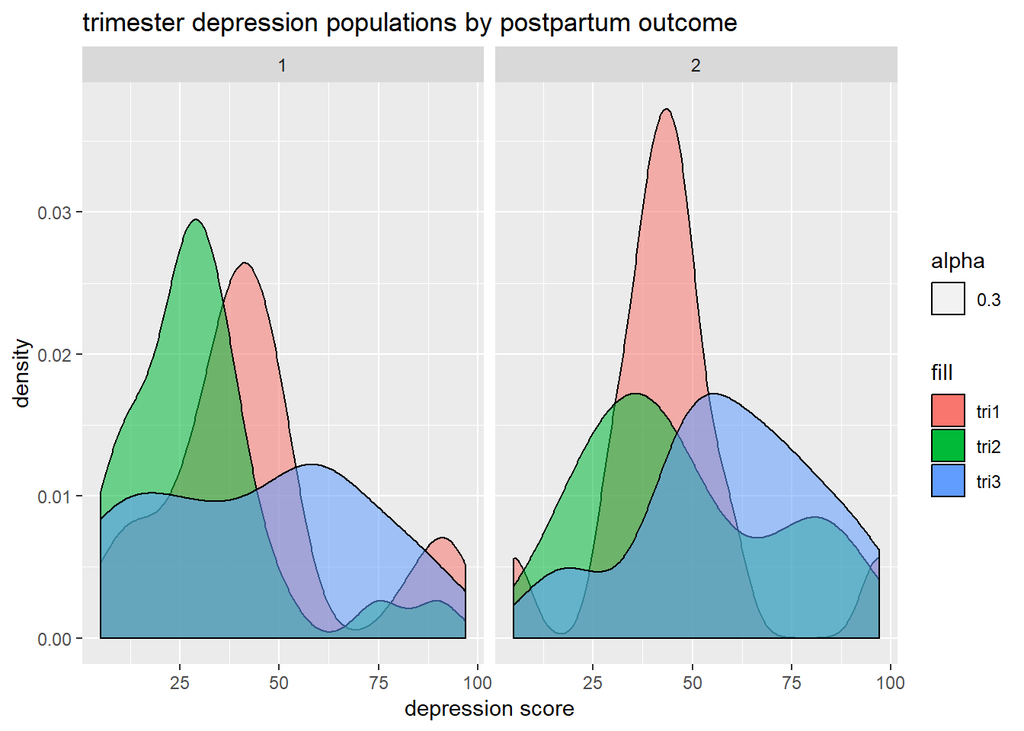

```r
#variation of depression scores in trimesters seperated by outcome of post partum depression or not

pp_sad %>% ggplot() + geom_density(aes(x=depression_tri1, fill='tri1', alpha = 0.3)) + geom_density(aes(x=depression_tri2, fill='tri2', alpha = 0.3)) + geom_density(aes(x=depression_tri3, fill='tri3', alpha = 0.3)) + facet_wrap(~postpartum_depression) + ggtitle('trimester depression populations by postpartum outcome') + xlab('depression score')
```

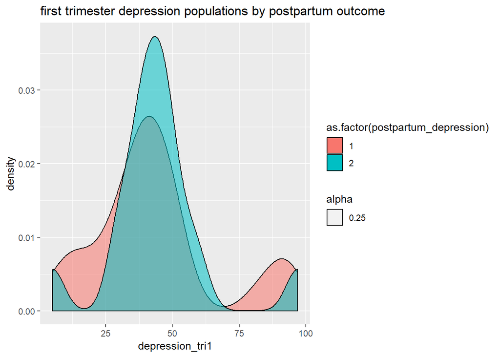

```r
pp_sad %>% ggplot() + geom_density(aes(x=depression_tri1, group=as.factor(postpartum_depression), fill=as.factor(postpartum_depression), alpha=0.25))+ ggtitle('first trimester depression populations by postpartum outcome')
```

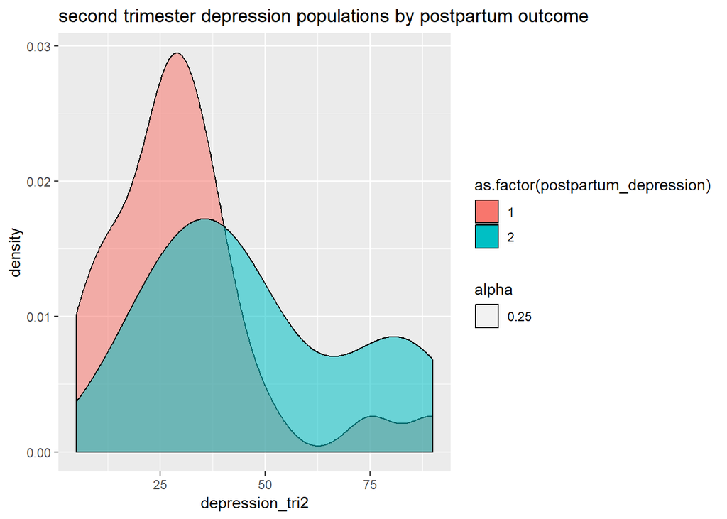

```r
pp_sad %>% ggplot() + geom_density(aes(x=depression_tri2, group=as.factor(postpartum_depression), fill=as.factor(postpartum_depression), alpha = 0.25))+ggtitle('second trimester depression populations by postpartum outcome')
```

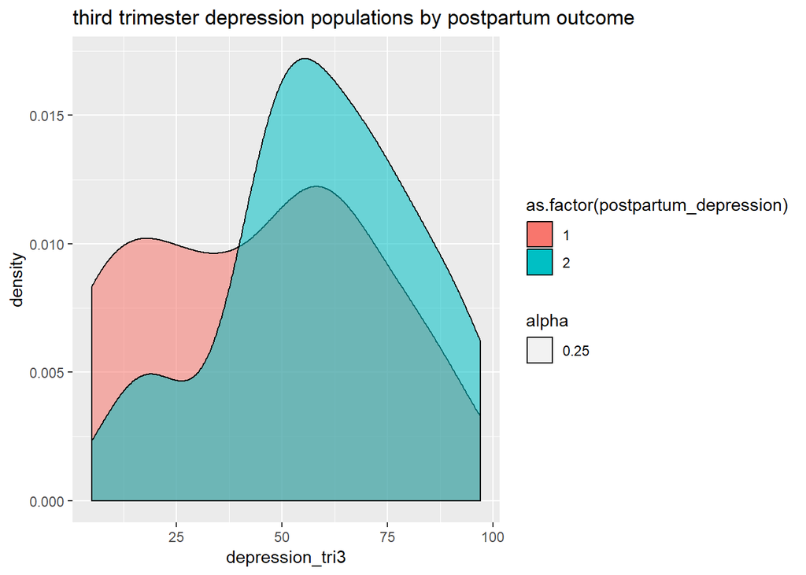

```r
pp_sad %>% ggplot() + geom_density(aes(x=depression_tri3, group=as.factor(postpartum_depression), fill=as.factor(postpartum_depression), alpha = 0.25))+ggtitle('third trimester depression populations by postpartum outcome')
```

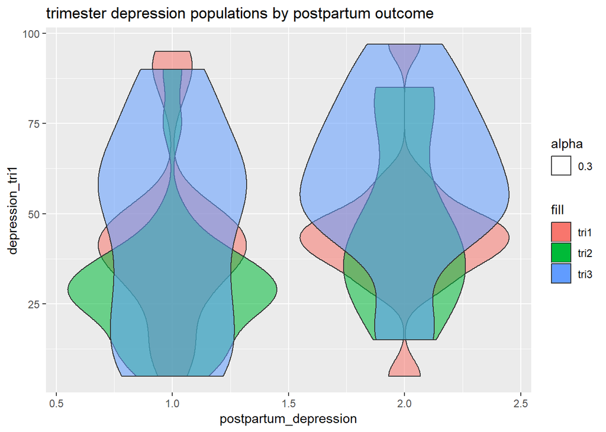

```r
pp_sad %>% ggplot() + geom_violin(aes(x=postpartum_depression,y=depression_tri1,group=postpartum_depression, fill='tri1', alpha=0.3)) + geom_violin(aes(x=postpartum_depression,y=depression_tri2,group=postpartum_depression, fill='tri2', alpha=0.3)) + geom_violin(aes(x=postpartum_depression,y=depression_tri3,group=postpartum_depression, fill='tri3', alpha=0.3))+ ggtitle('trimester depression populations by postpartum outcome')
```

```r
#same info shown in boxplots
#ggplot(pp_sad,aes(x=postpartum_depression,y=depression_tri1,group=postpartum_depression,fill=as.factor(postpartum_depression)))+
 # geom_boxplot()+
  #theme_gray()
#ggplot(pp_sad,aes(x=postpartum_depression,y=depression_tri2,group=postpartum_depression,fill=as.factor(postpartum_depression)))+
 # geom_boxplot()+
  #theme_gray()
#ggplot(pp_sad,aes(x=postpartum_depression,y=depression_tri3,group=postpartum_depression,fill=as.factor(postpartum_depression)))+
 # geom_boxplot()+
  #theme_gray()
```

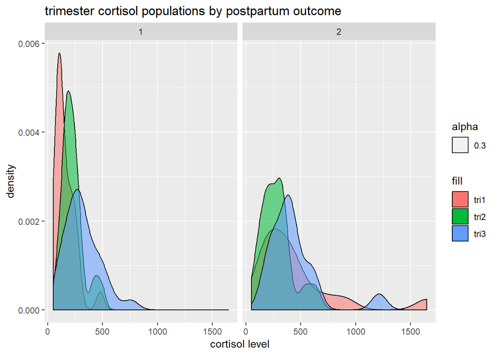

```r
pp_sad %>% ggplot() + geom_density(aes(x=cortisol_tri1, fill='tri1', alpha = 0.3)) + geom_density(aes(x=cortisol_tri2, fill='tri2', alpha = 0.3)) + geom_density(aes(x=cortisol_tri3, fill='tri3', alpha = 0.3)) + facet_wrap(~postpartum_depression) + ggtitle('trimester cortisol populations by postpartum outcome') + xlab('cortisol level')
```

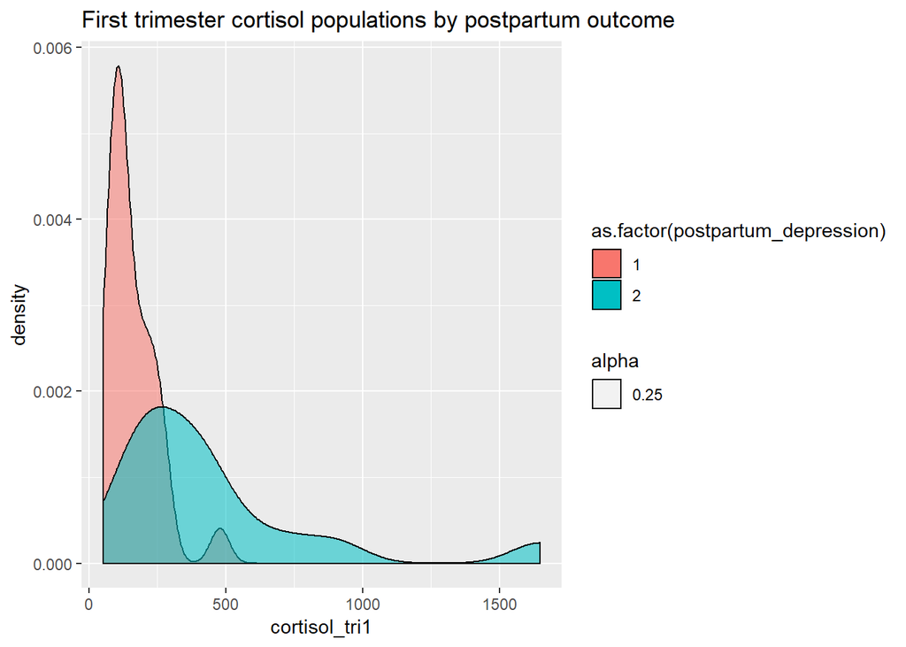

```r
pp_sad %>% ggplot() + geom_density(aes(x=cortisol_tri1, group=as.factor(postpartum_depression), fill=as.factor(postpartum_depression), alpha=0.25))+ ggtitle('First trimester cortisol populations by postpartum outcome')
```

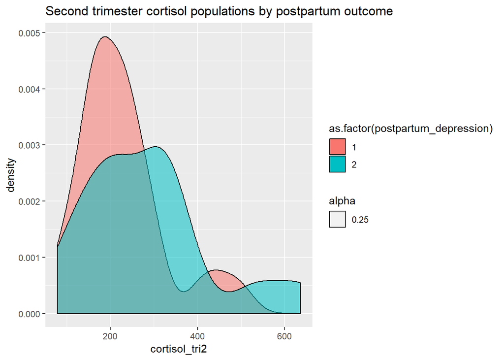

```r
pp_sad %>% ggplot() + geom_density(aes(x=cortisol_tri2, group=as.factor(postpartum_depression), fill=as.factor(postpartum_depression), alpha = 0.25))+ ggtitle('Second trimester cortisol populations by postpartum outcome')
```

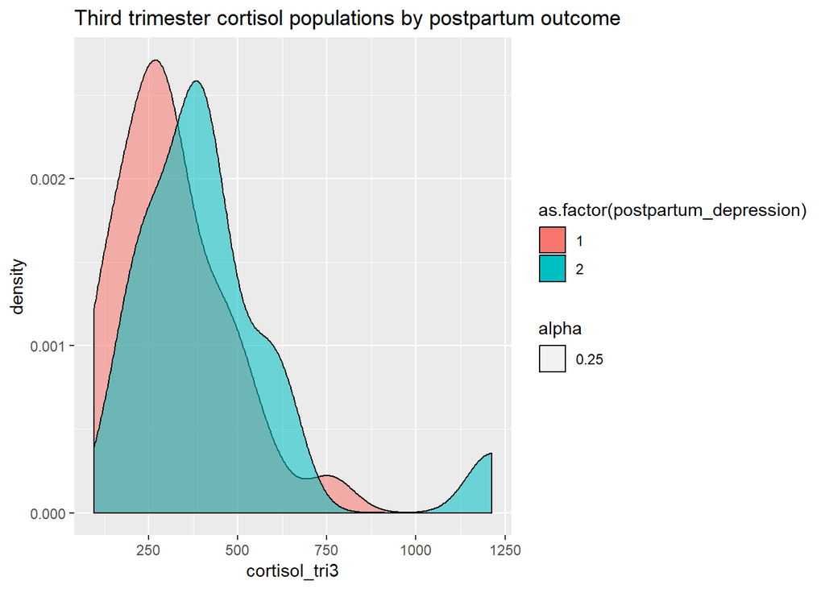

```r
pp_sad %>% ggplot() + geom_density(aes(x=cortisol_tri3, group=as.factor(postpartum_depression), fill=as.factor(postpartum_depression), alpha = 0.25))+ ggtitle('Third trimester cortisol populations by postpartum outcome')
```

## 3.3 PP_depression vs Employment Status

### 3.3.1 Relationship between postpartum depression and employment status

it seemed important to investigate other sources of cortisol increase as the stress from being emoployed or not seeme like it would have an effect on the cortisol levles of the individual as well as the depression scores related. as such thoughs two paramaters were compaired to employment status. How ever neither difference was was very drastic.

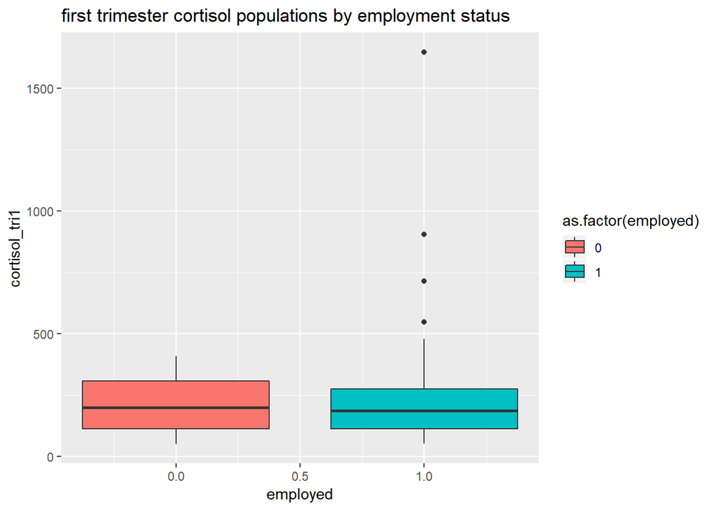

```r
ggplot(pp_sad,aes(x=employed,y=cortisol_tri1,group=employed,fill=as.factor(employed)))+
  geom_boxplot()+
  ggtitle('first trimester cortisol populations by employment status')+
  theme_gray()
```

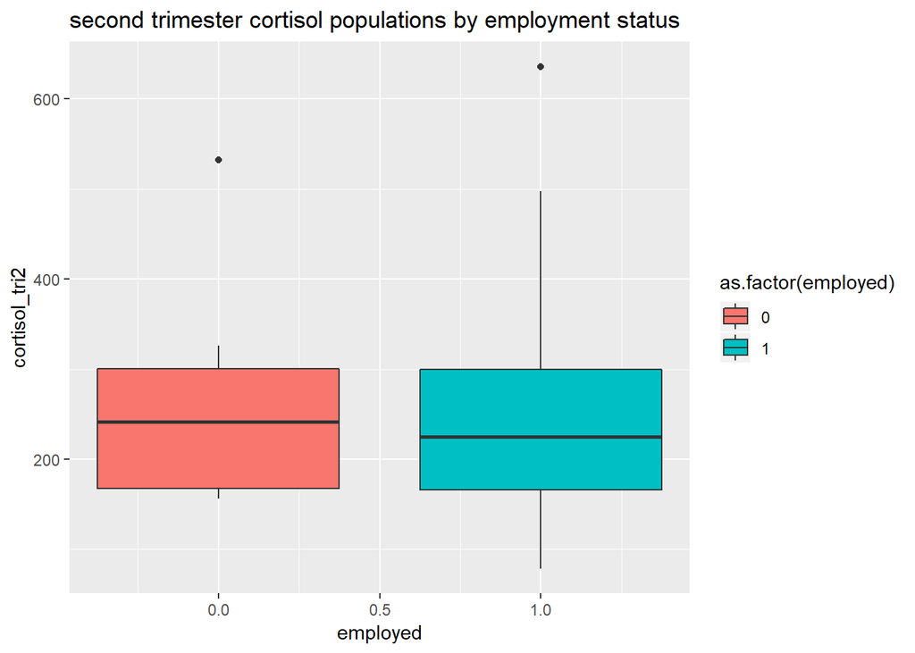

```r
ggplot(pp_sad,aes(x=employed,y=cortisol_tri2,group=employed,fill=as.factor(employed)))+
  geom_boxplot()+
  ggtitle('second trimester cortisol populations by employment status')+
  theme_gray()
```

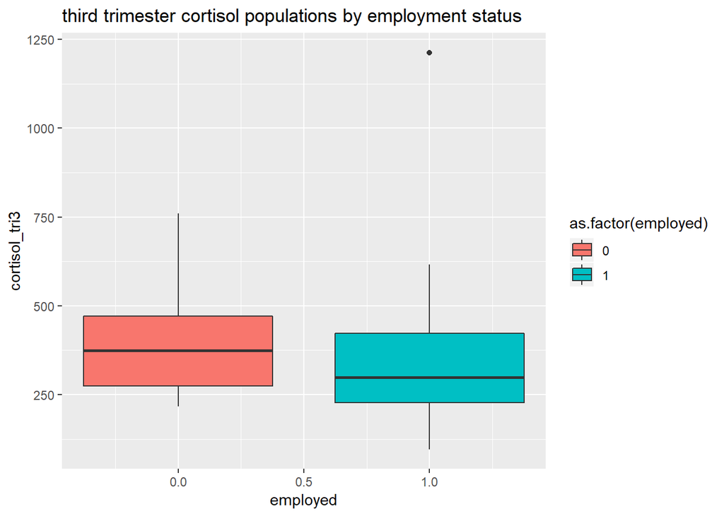

```r
ggplot(pp_sad,aes(x=employed,y=cortisol_tri3,group=employed,fill=as.factor(employed)))+
  geom_boxplot()+
  ggtitle('third trimester cortisol populations by employment status')+
  theme_gray()
```

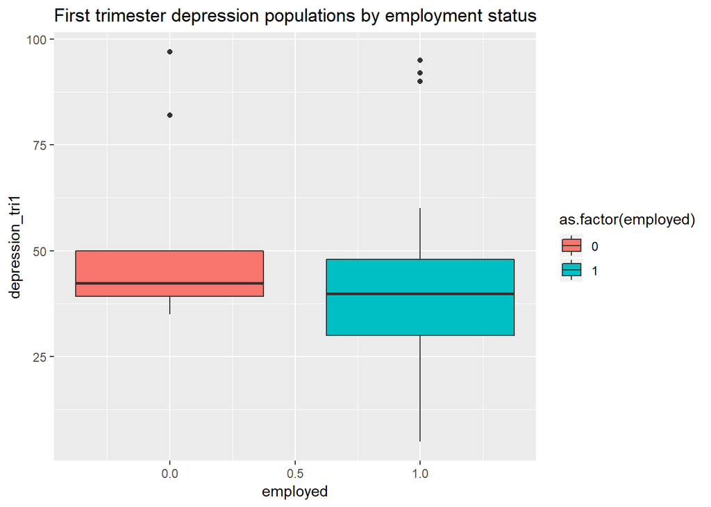

```r
ggplot(pp_sad,aes(x=employed,y=depression_tri1,group=employed,fill=as.factor(employed)))+
  geom_boxplot()+
  ggtitle('First trimester depression populations by employment status')+
  theme_gray()
```

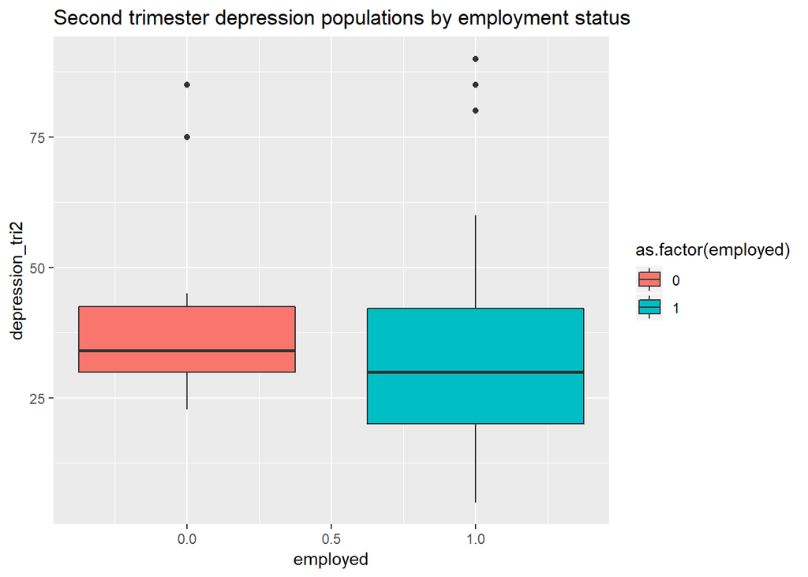

```r
ggplot(pp_sad,aes(x=employed,y=depression_tri2,group=employed,fill=as.factor(employed)))+
  geom_boxplot()+
  ggtitle('Second trimester depression populations by employment status')+
  theme_gray()
```

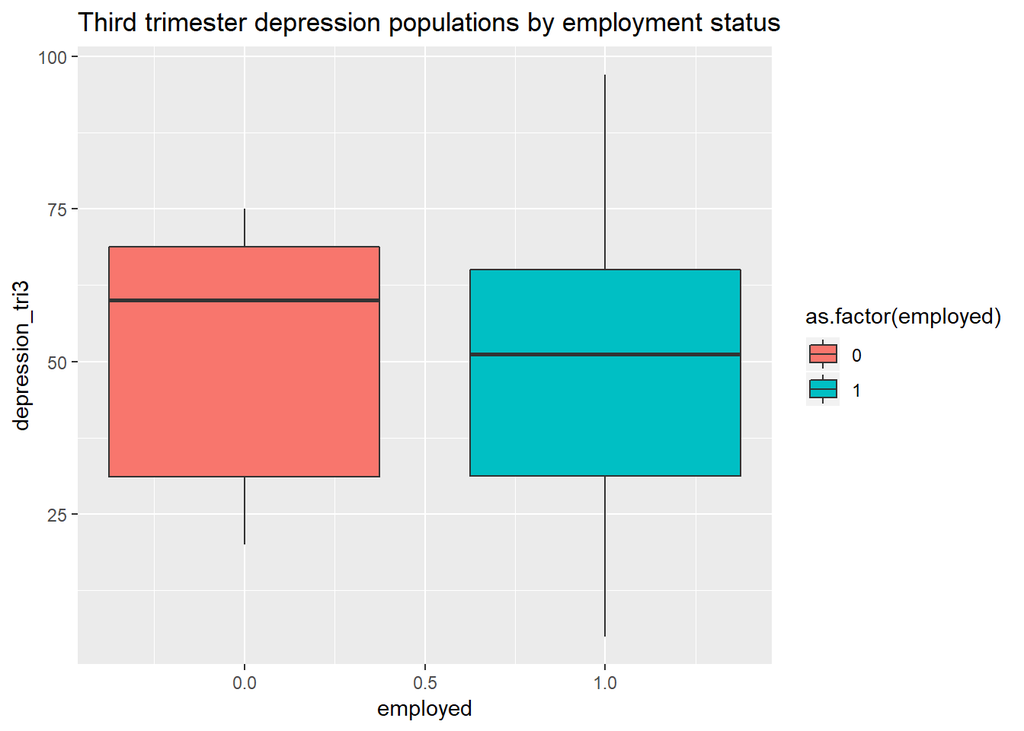

```r
ggplot(pp_sad,aes(x=employed,y=depression_tri3,group=employed,fill=as.factor(employed)))+
  geom_boxplot()+
  ggtitle('Third trimester depression populations by employment status')+
  theme_gray()
```

## 3.4 Depression Score vs Cortisol

### 3.4.1 Relationship between job type and depression score and cortosol levels

we also investigated the relationship between job type and cortosol and depression scores as we thought that this two would affect the results. there does seem to be some correlation here between having a job and depression score but not so much cortosol levels.

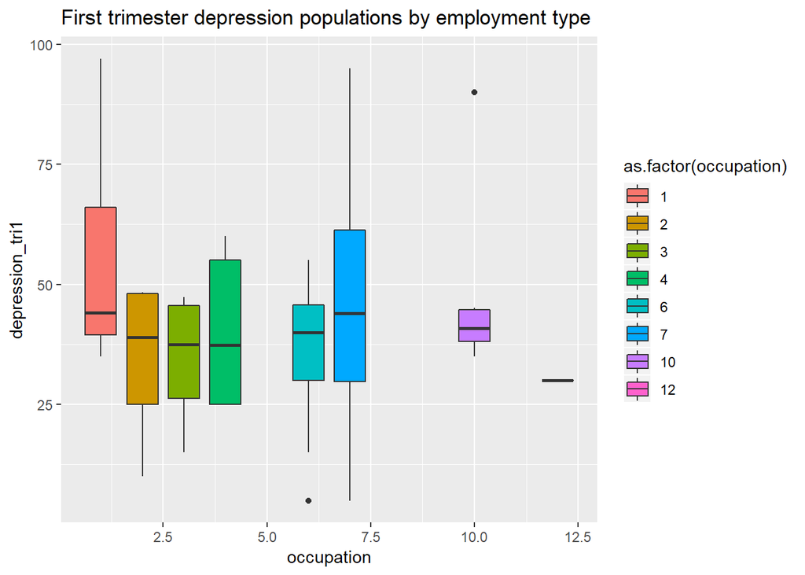

```r
ggplot(pp_sad,aes(x=occupation,y=depression_tri1,group=occupation,fill=as.factor(occupation)))+
  geom_boxplot()+
  ggtitle('First trimester depression populations by employment type')+
  theme_gray()
```

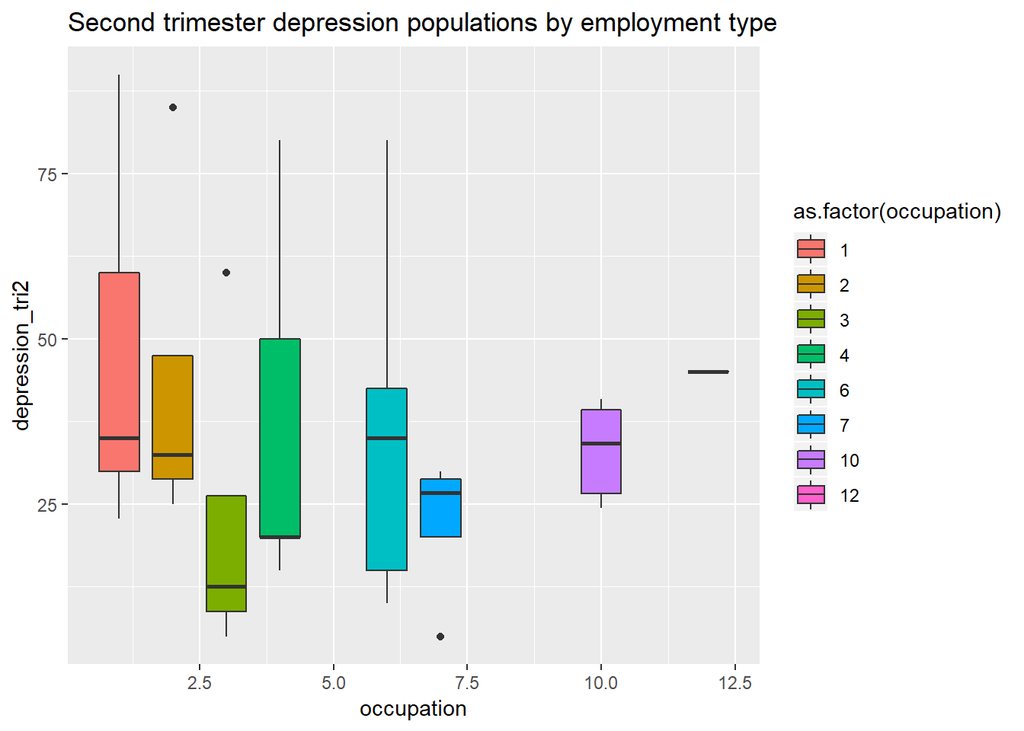

```r
ggplot(pp_sad,aes(x=occupation,y=depression_tri2,group=occupation,fill=as.factor(occupation)))+
  geom_boxplot()+
  ggtitle('Second trimester depression populations by employment type')+
  theme_gray()
```

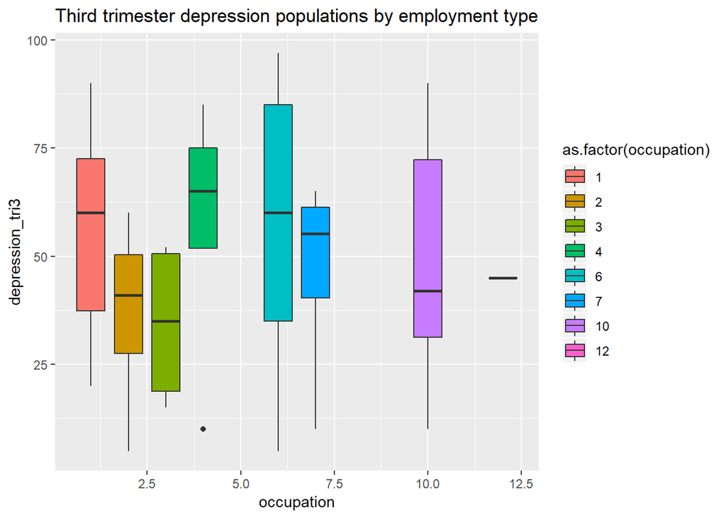

```r
ggplot(pp_sad,aes(x=occupation,y=depression_tri3,group=occupation,fill=as.factor(occupation)))+
  geom_boxplot()+
  ggtitle('Third trimester depression populations by employment type')+
  theme_gray()
```

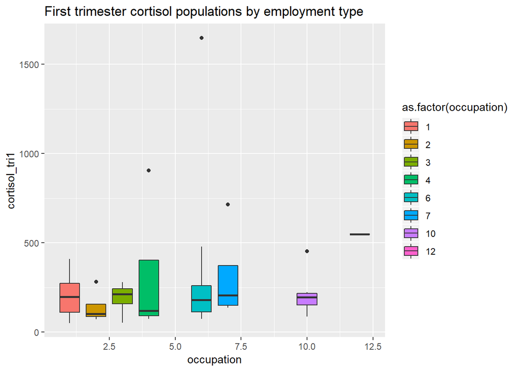

```r
ggplot(pp_sad,aes(x=occupation,y=cortisol_tri1,group=occupation,fill=as.factor(occupation)))+
  geom_boxplot()+
  ggtitle('First trimester cortisol populations by employment type')+
  theme_gray()
```

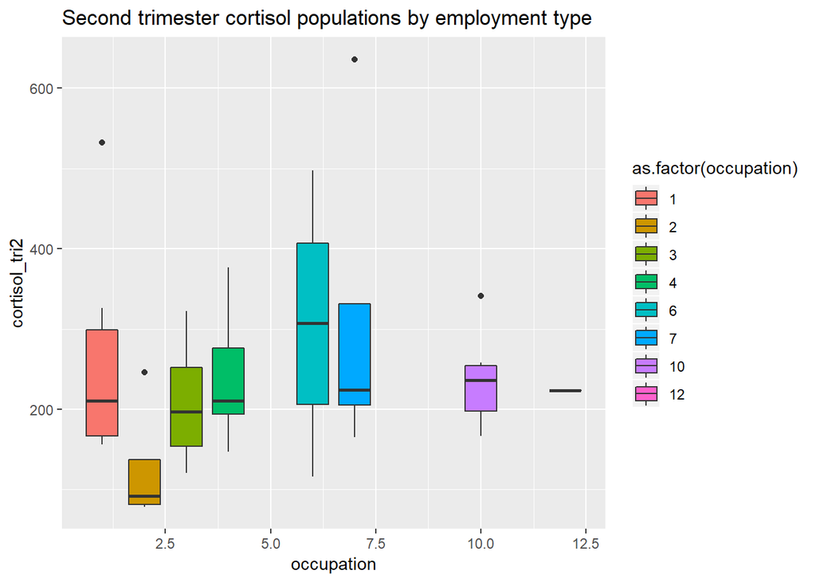

```r
ggplot(pp_sad,aes(x=occupation,y=cortisol_tri2,group=occupation,fill=as.factor(occupation)))+
  geom_boxplot()+
  ggtitle('Second trimester cortisol populations by employment type')+
  theme_gray()
```

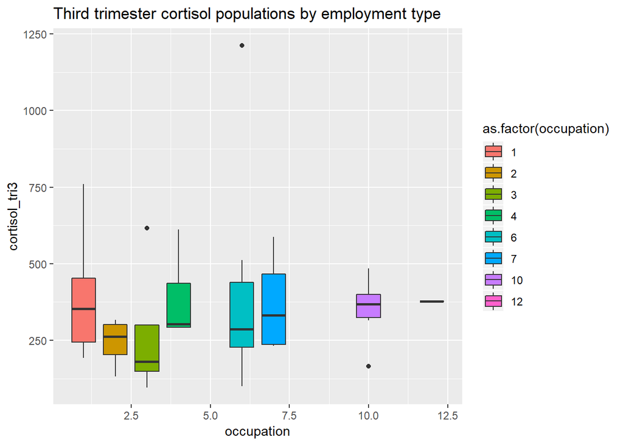

```r
ggplot(pp_sad,aes(x=occupation,y=cortisol_tri3,group=occupation,fill=as.factor(occupation)))+
  geom_boxplot()+
  ggtitle('Third trimester cortisol populations by employment type')+
  theme_gray()
```

## 3.5 Occupation vs Postpartum depression

while employment type dosent seem to have to much of an effect on postpartum depression it would seem that being unemployed does

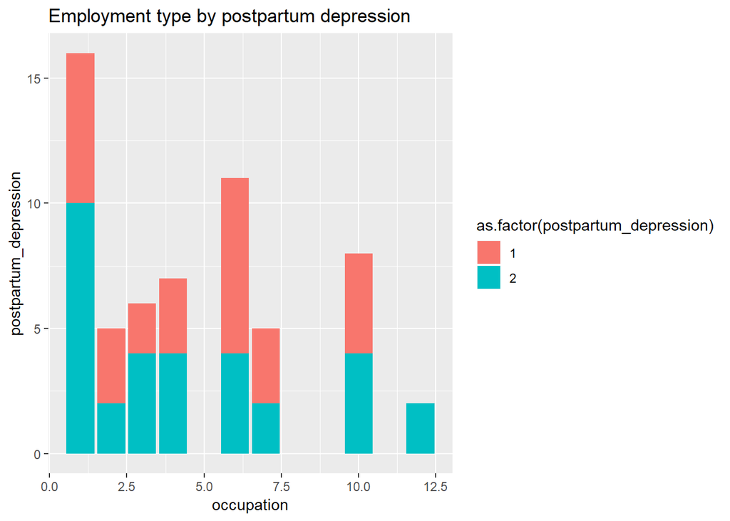

```r
ggplot(pp_sad,aes(x=occupation,y=postpartum_depression,fill=as.factor(postpartum_depression)))+
  geom_col()+
  ggtitle('Employment type by postpartum depression')+
  theme_gray()
```

## 3.6 Employment vs Postpartum depression

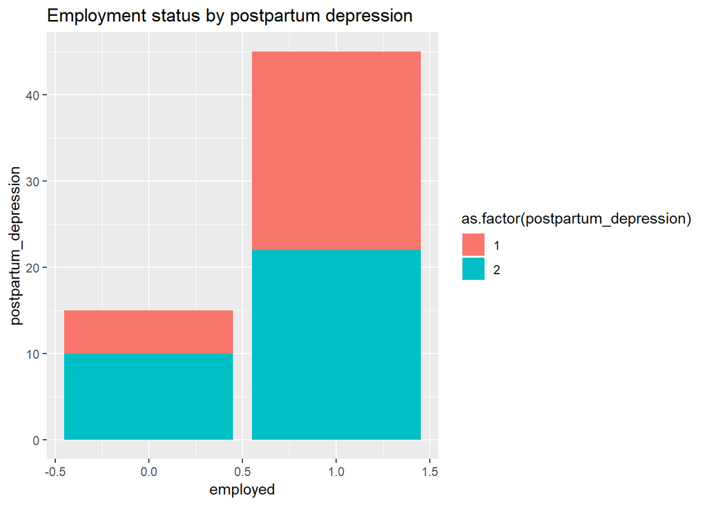

```r
ggplot(pp_sad,aes(x=employed,y=postpartum_depression,fill=as.factor(postpartum_depression)))+
  geom_col()+
  ggtitle('Employment status by postpartum depression')+
  theme_gray()
```

## 3.7 Wanted/Unwanted vs PP_depression

This seemed to have remarkably little affect

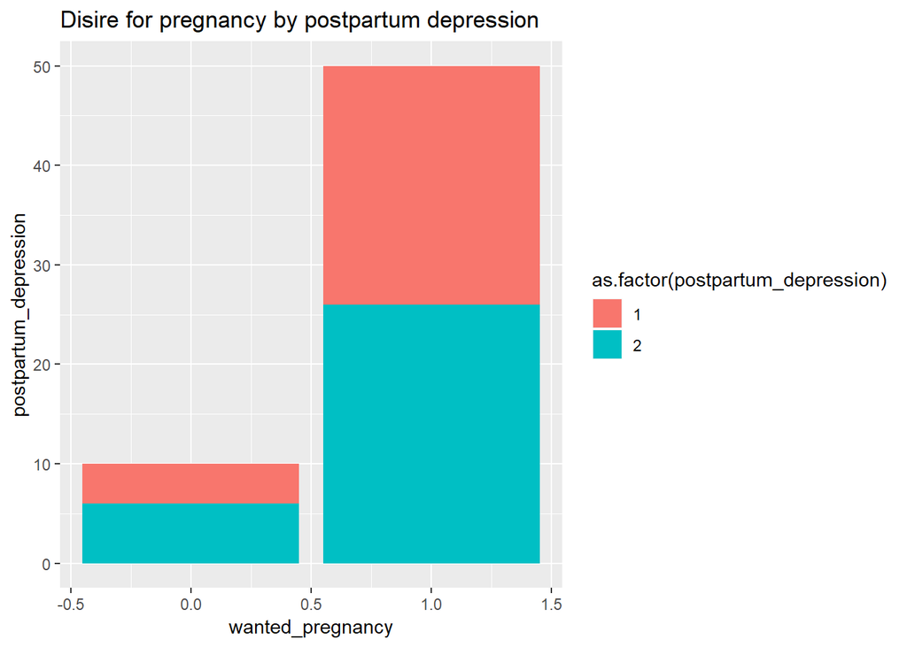

```r
ggplot(pp_sad,aes(x=wanted_pregnancy,y=postpartum_depression,fill=as.factor(postpartum_depression)))+
  geom_col()+
  ggtitle('Disire for pregnancy by postpartum depression')+
  theme_gray()
```

## 3.8 First Pregnancy vs PP_depression

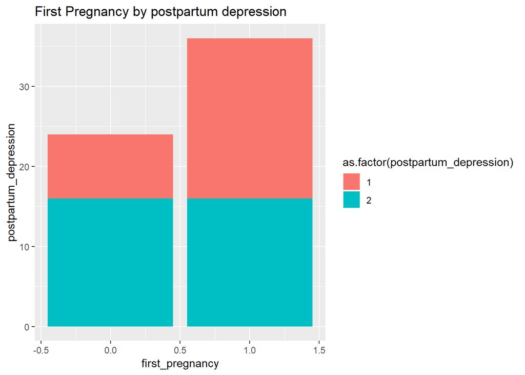

```r
ggplot(pp_sad,aes(x=first_pregnancy,y=postpartum_depression,fill=as.factor(postpartum_depression)))+
  geom_col()+
  ggtitle('First Pregnancy by postpartum depression')+
  theme_gray()
```

## 3.9 Sex of Fetus vs Depression

We investigated the affect of fetal sex on post partum depression and found the possiple corrilation between fetal sex and depression mentioned in the paper, I does seem though that the cortisol levels equalise at the third trimester.

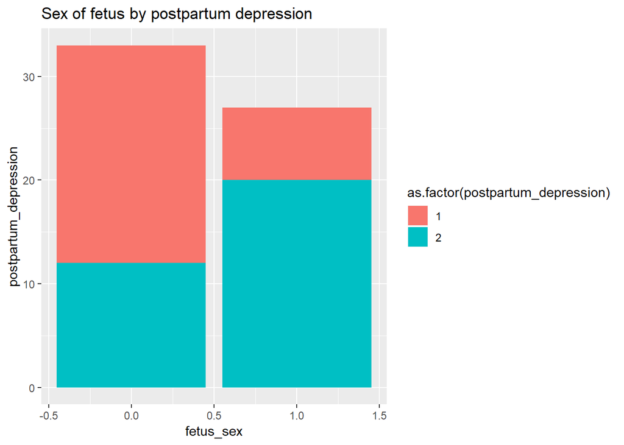

```r
ggplot(pp_sad,aes(x=fetus_sex,y=postpartum_depression,fill=as.factor(postpartum_depression)))+
  geom_col()+
  ggtitle('Sex of fetus by postpartum depression')+
  theme_gray()
```

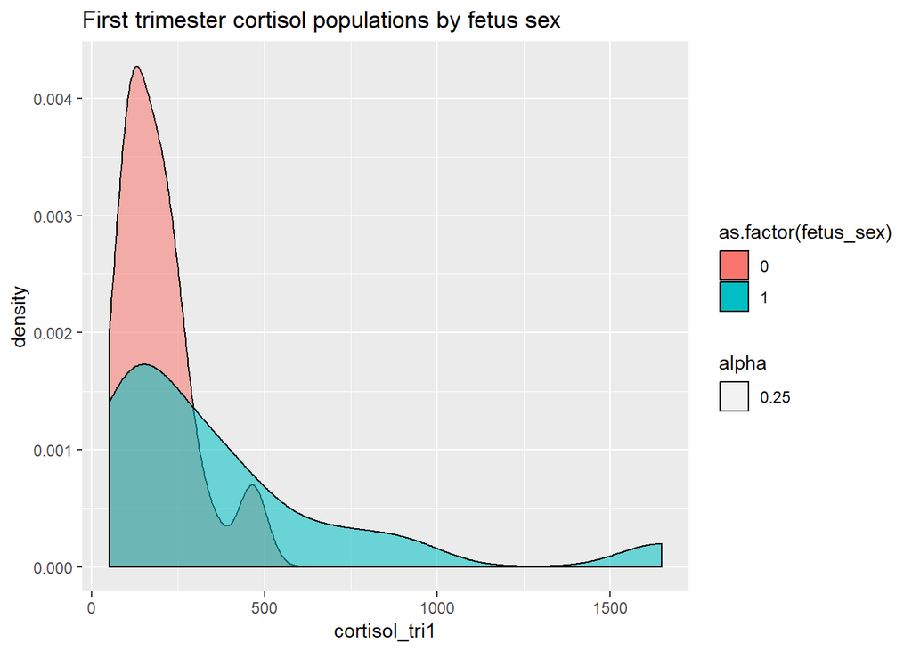

```r
pp_sad %>% ggplot() +
  geom_density(aes(x=cortisol_tri1, group=as.factor(fetus_sex), fill=as.factor(fetus_sex), alpha = 0.25))+
  ggtitle('First trimester cortisol populations by fetus sex')
```

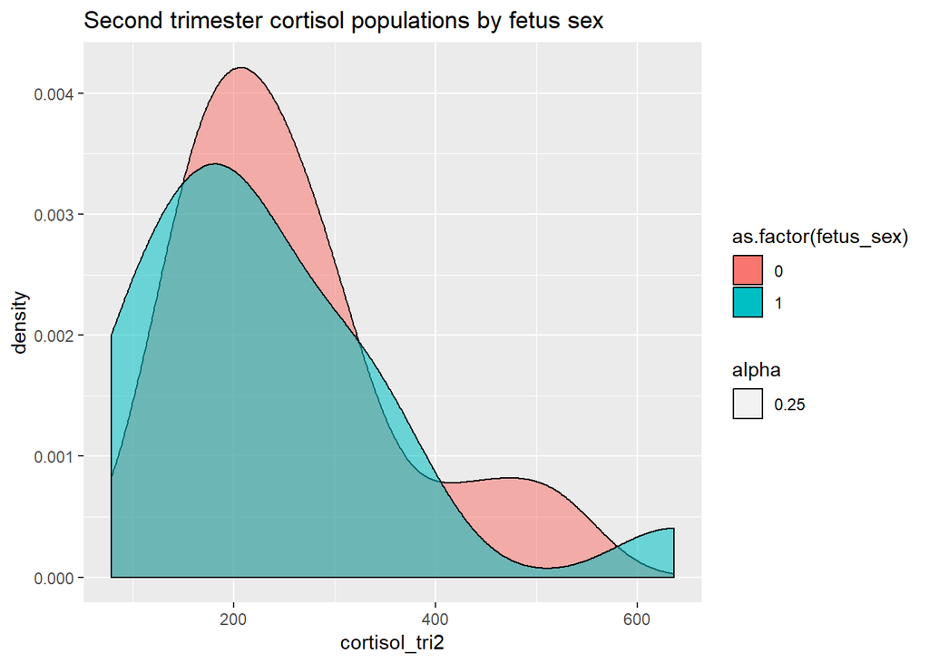

```r
pp_sad %>% ggplot() +
  geom_density(aes(x=cortisol_tri2, group=as.factor(fetus_sex), fill=as.factor(fetus_sex), alpha = 0.25))+
  ggtitle('Second trimester cortisol populations by fetus sex')
```

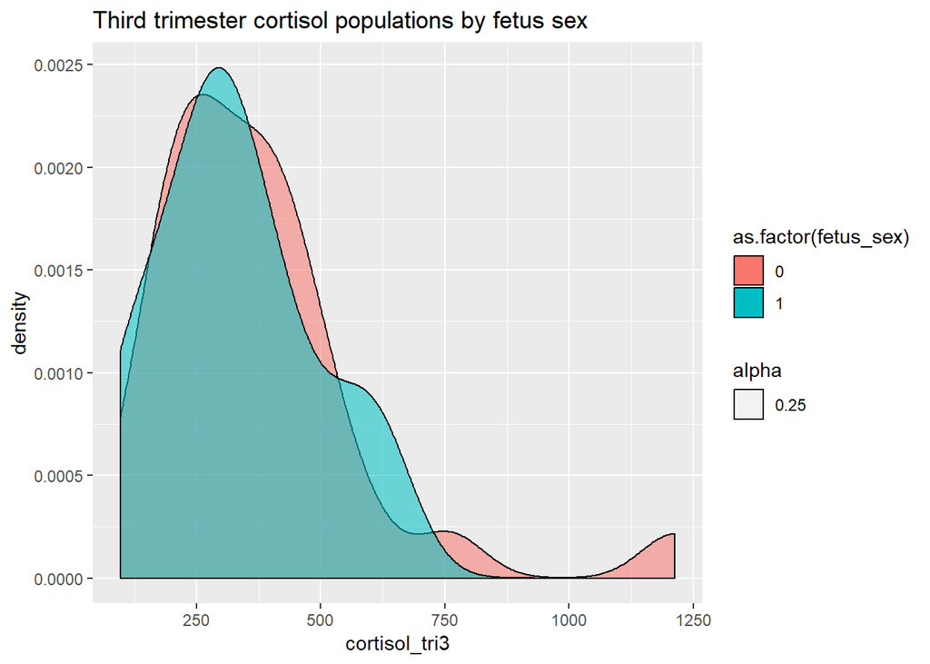

```r
pp_sad %>% ggplot() +
  geom_density(aes(x=cortisol_tri3, group=as.factor(fetus_sex), fill=as.factor(fetus_sex), alpha = 0.25))+
  ggtitle('Third trimester cortisol populations by fetus sex')
```